# Exploration of Prosper Loan Data by David Shahrestani

# Introduction

[Prosper loan data](https://docs.google.com/document/d/1qEcwltBMlRYZT-l699-71TzInWfk4W9q5rTCSvDVMpc/pub?embedded=true) provided by Udacity (last updated 3/11/14)

[Prosper.com](https://www.prosper.com/landing) is a peer-to-peer lending marketplace. Borrowers request personal loans on Prosper and investors (individual or institutional) can fund anywhere from $2,000 to $35,000 per loan request. In addition to credit scores, ratings, and histories, investors can consider borrowers’ personal loan descriptions, endorsements from friends, and community affiliations. Prosper handles the servicing of the loan and collects and distributes borrower payments and interest back to the loan investors.

I will explore this data set with the goal of understanding the relationships between [Prosper’s lending variables](https://docs.google.com/spreadsheets/d/1gDyi_L4UvIrLTEC6Wri5nbaMmkGmLQBk-Yx3z0XDEtI/edit#gid=0) and possibly using them to make predictions.

# Load and structure the data

```
## [1] 113937     81
```

The data set contains an overwhelming 81 variables for analysis. I have chosen 17 variables that I feel best serve my objective for this project. These variables are as follows:

#### Loan Profile:

- LoanStatus: The current status of the loan: “Current or Paid”, “Past Due”, “Defaulted or Chargedoff”.
- LoanOriginationDate: The date the loan was originated.
- Term: The length of the loan expressed in months.
- TimeUntilClosed: ClosedDate - LoanOriginationDate. A custom variable in months.
- ListingCategory: The category of the listing that the borrower selected when posting their listing.
- BorrowerRate: The Borrower’s interest rate for the loan.
- LoanCurrentDaysDelinquent: The number of days delinquent.

#### Borrower Profile:

- BorrowerState: The two letter abbreviation of the state of the address of the borrower at the time the Listing was created.
- Recommendations: Number of recommendations the borrower had at the time the listing was created.
- IsBorrowerHomeowner: A Borrower will be classified as a homeowner if they have a mortgage on their credit profile or provide documentation confirming they are a homeowner.
- StatedMonthlyIncome: The monthly income the borrower stated at the time the listing was created.

#### Credit Profile:

- CreditScore: Credit score averaged from consumer credit rating agencies.
- BankcardUtilization: The percentage of available revolving credit that is utilized at the time the credit profile was pulled.
- CurrentDelinquencies: Number of accounts delinquent at the time the credit profile was pulled.
- InquiriesLast6Months: Number of inquiries in the past six months at the time the credit profile was pulled.
- DebtToIncomeRatio: The debt to income ratio of the borrower at the time the credit profile was pulled. This value is Null if the debt to income ratio is not available. This value is capped at 10.01 (any debt to income ratio larger than 1000% will be returned as 1001%).
- PublicRecordsLast10Years: Number of public records in the past 10 years at the time the credit profile was pulled.

```
## 'data.frame':    113932 obs. of  17 variables:
##  $ LoanStatus               : Ord.factor w/ 3 levels "Defaulted or Chargedoff"<..: 3 3 3 3 3 3 3 3 3 3 ...
##  $ LoanOriginationDate      : Date, format: "2005-11-15" "2005-11-18" ...
##  $ Term                     : Ord.factor w/ 3 levels "12"<"36"<"60": 2 2 2 2 2 2 2 2 2 2 ...
##  $ TimeUntilClosed          : num  0.3 0.4 1.5 1.6 0.2 10.9 1.4 0 27.6 0 ...
##  $ ListingCategory          : Factor w/ 21 levels "Not available",..: 1 1 1 1 1 1 1 1 1 1 ...
##  $ BorrowerRate             : num  0.04 0.17 0.25 0.13 0.0435 0.12 0.09 0.085 0.13 0.12 ...
##  $ LoanCurrentDaysDelinquent: int  0 0 0 0 0 0 0 0 0 0 ...
##  $ BorrowerState            : Factor w/ 52 levels "","AK","AL","AR",..: 1 1 1 1 1 1 1 1 1 1 ...
##  $ Recommendations          : int  0 0 0 0 0 0 0 0 0 0 ...
##  $ IsBorrowerHomeowner      : Factor w/ 2 levels "False","True": 1 1 1 1 1 1 1 1 1 1 ...
##  $ StatedMonthlyIncome      : num  12500 10000 29167 8333 9167 ...
##  $ CreditScore              : num  NA NA NA NA NA NA NA NA NA NA ...
##  $ BankcardUtilization      : num  NA NA NA NA NA NA NA NA NA NA ...
##  $ CurrentDelinquencies     : int  NA NA NA NA NA NA NA NA NA NA ...
##  $ InquiriesLast6Months     : int  NA NA NA NA NA NA NA NA NA NA ...
##  $ DebtToIncomeRatio        : num  0.2328 0.0178 0.0123 0.0129 0.0412 ...
##  $ PublicRecordsLast10Years : int  NA NA NA NA NA NA NA NA NA NA ...
```

# Univariate Plots Section

### Summary:

```
##                    LoanStatus    LoanOriginationDate  Term
##  Defaulted or Chargedoff:17010   Min.   :2005-11-15   12: 1614
##  Past Due               : 2067   1st Qu.:2008-10-02   36:87773
##  Current or Paid        :94855   Median :2012-06-26   60:24545
##                                  Mean   :2011-07-21
##                                  3rd Qu.:2013-09-18
##                                  Max.   :2014-03-12
##
##  TimeUntilClosed           ListingCategory   BorrowerRate
##  Min.   :-45.6   Debt consolidation:58307   Min.   :0.0000
##  1st Qu.:  9.2   Not available     :16961   1st Qu.:0.1340
##  Median : 17.1   Other             :10494   Median :0.1840
##  Mean   : 19.3   Home improvement  : 7433   Mean   :0.1928
##  3rd Qu.: 31.0   Business          : 7189   3rd Qu.:0.2500
##  Max.   : 51.2   Auto              : 2572   Max.   :0.4975
##  NA's   :58848   (Other)           :10976
##  LoanCurrentDaysDelinquent BorrowerState   Recommendations
##  Min.   :   0.0            CA     :14717   Min.   : 0.00000
##  1st Qu.:   0.0            TX     : 6842   1st Qu.: 0.00000
##  Median :   0.0            NY     : 6729   Median : 0.00000
##  Mean   : 152.8            FL     : 6719   Mean   : 0.04803
##  3rd Qu.:   0.0            IL     : 5921   3rd Qu.: 0.00000
##  Max.   :2704.0                   : 5512   Max.   :39.00000
##                            (Other):67492
##  IsBorrowerHomeowner StatedMonthlyIncome  CreditScore
##  False:56456         Min.   :      0     Min.   : 10.0
##  True :57476         1st Qu.:   3201     1st Qu.:670.0
##                      Median :   4667     Median :690.0
##                      Mean   :   5608     Mean   :695.6
##                      3rd Qu.:   6828     3rd Qu.:730.0
##                      Max.   :1750003     Max.   :890.0
##                                          NA's   :590
##  BankcardUtilization CurrentDelinquencies InquiriesLast6Months
##  Min.   :0.000       Min.   : 0.000       Min.   :  0.000
##  1st Qu.:0.310       1st Qu.: 0.000       1st Qu.:  0.000
##  Median :0.600       Median : 0.000       Median :  1.000
##  Mean   :0.561       Mean   : 0.592       Mean   :  1.435
##  3rd Qu.:0.840       3rd Qu.: 0.000       3rd Qu.:  2.000
##  Max.   :5.950       Max.   :83.000       Max.   :105.000
##  NA's   :7600        NA's   :696          NA's   :696
##  DebtToIncomeRatio PublicRecordsLast10Years
##  Min.   : 0.000    Min.   : 0.0000
##  1st Qu.: 0.140    1st Qu.: 0.0000
##  Median : 0.220    Median : 0.0000
##  Mean   : 0.276    Mean   : 0.3126
##  3rd Qu.: 0.320    3rd Qu.: 0.0000
##  Max.   :10.010    Max.   :38.0000
##  NA's   :8554      NA's   :696
```

Most of the loans are current or paid. Most of the loans are used for Debt consolidation. The average interest rate for loans is 19%. California has, by far, the most loans. About half of borrowers are homeowners. The median monthly income of borrowers is $4,667. The max monthly income is $1,750,003. The average credit score of borrowers is 695.

### Loan Profile Variables:

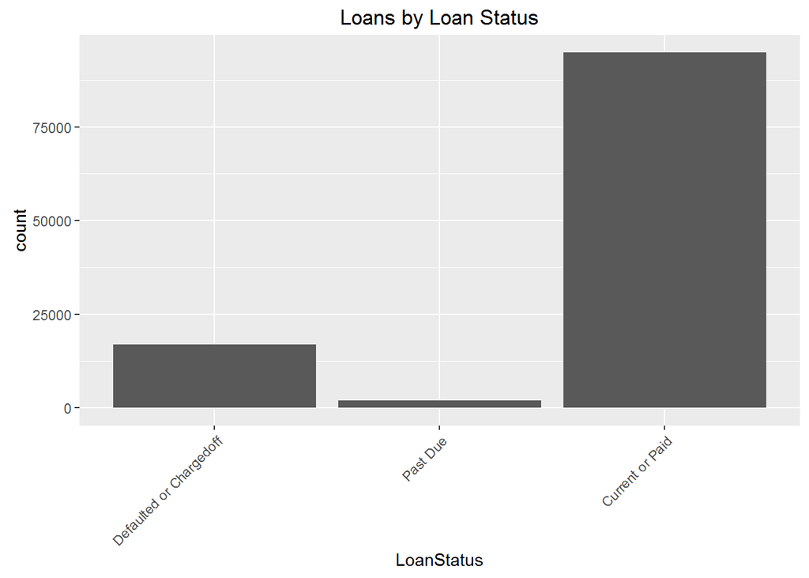

```
## Defaulted or Chargedoff                Past Due         Current or Paid
##                   17010                    2067                   94855
```

The majority of loans are current or paid. I wonder how other factors will affect the status of the loans. I will explore this further in later sections.

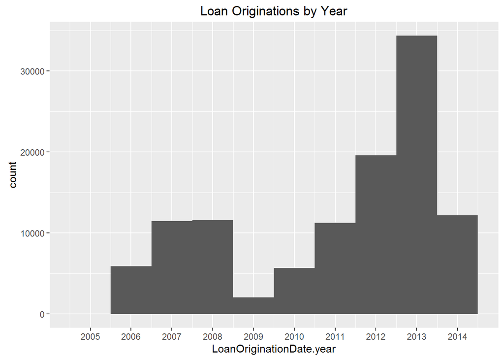

```
##
##  2005  2006  2007  2008  2009  2010  2011  2012  2013  2014
##    22  5902 11460 11551  2047  5652 11228 19553 34345 12172
```

Loan originations dropped off dramatically in 2009. This corresponds with the great recession and makes sense intuitively. Upon further investigation, the spike in 2013 corresponds to [press releases](https://www.prosper.com/about-us/2013/04/30/prosper-reports-record-month-in-april/) about the lending industry as a whole experiencing a spike in demand. This could be caused by increased institutional activity in the space.

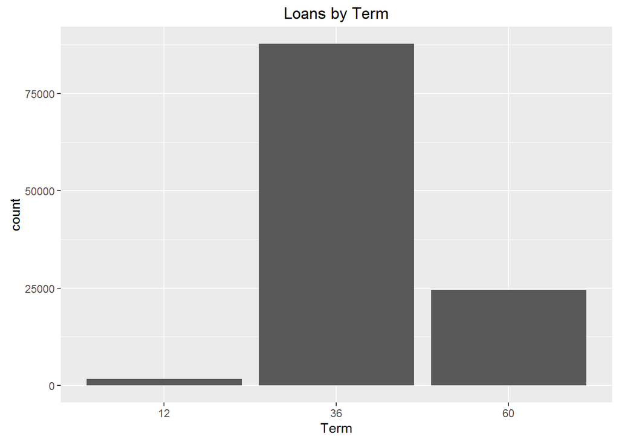

```
##
##    12    36    60
##  1614 87773 24545
```

The majority of loan terms are 36 months. 12 month terms are the least frequent, which makes sense since Prosper stopped offering 12 month loans.

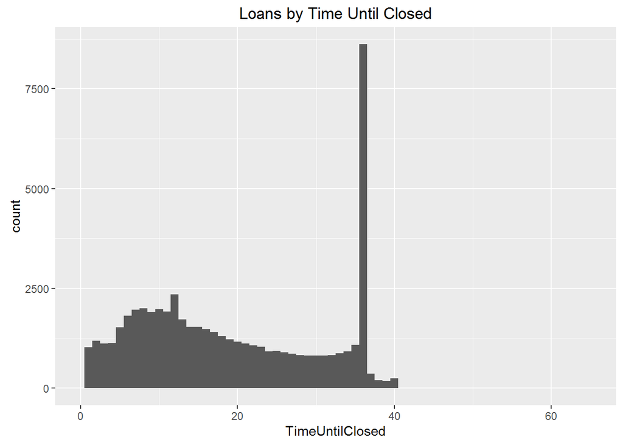

Loan terms for Prosper consisted of 12, 36, and 60 month terms. This makes the two peaks at 12 and 36 make sense. There was one data point that had a negative time. This appears to be a data entry mistake. The lack of loans making it to the full 60 month term suggests to me that a lot of loans are either prepayed or go into default before 5 years passes.

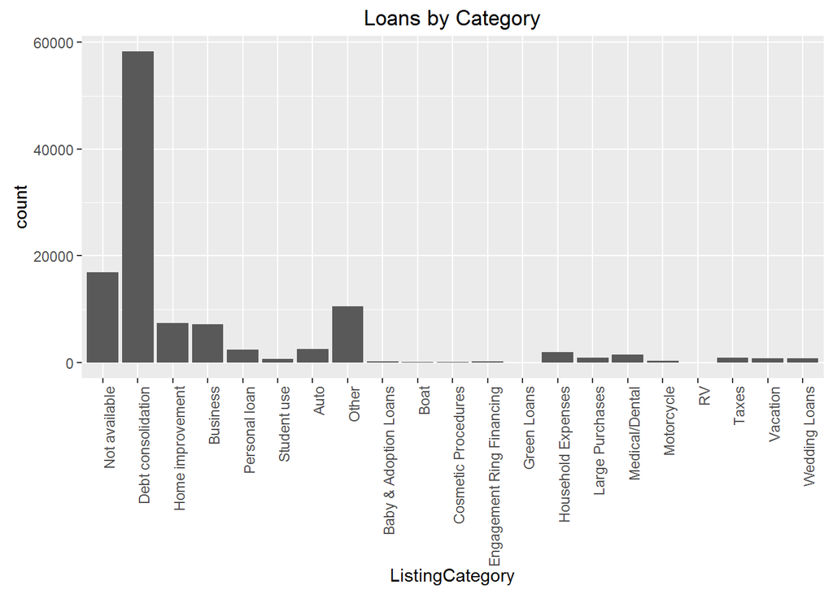

The most loans are used for debt consolidation and the least loans are used to purchase RVs. There is also a large number of loans that are not identified.

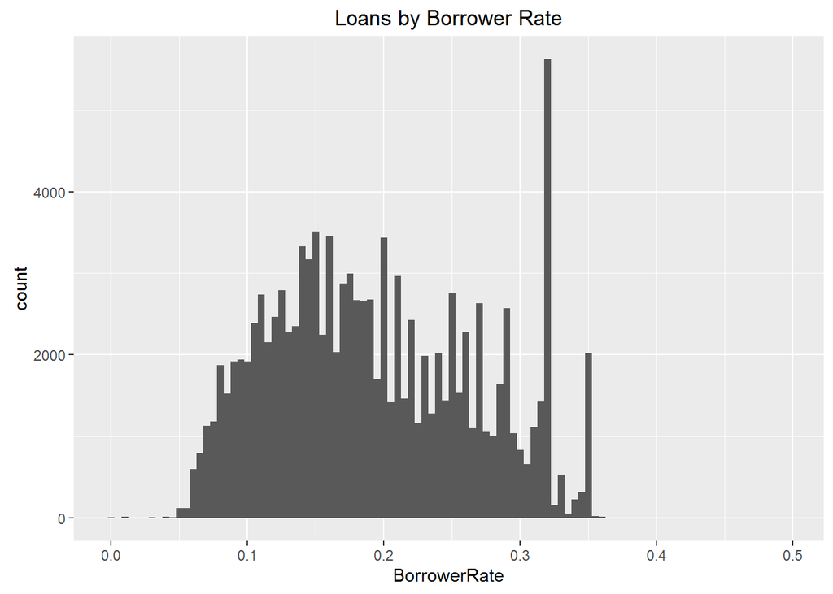

```
##
##  FALSE   TRUE
## 113924      8
```

The borrower rate is normally distributed with some significant outliers. Between .30 and .35, there is a large spike in loan count. This will need a closer look in later sections.

There are also 8 instances where the rate is 0 which can be seen in the table under the true value. Upon futher investigation, the APR for these loans is still positive.

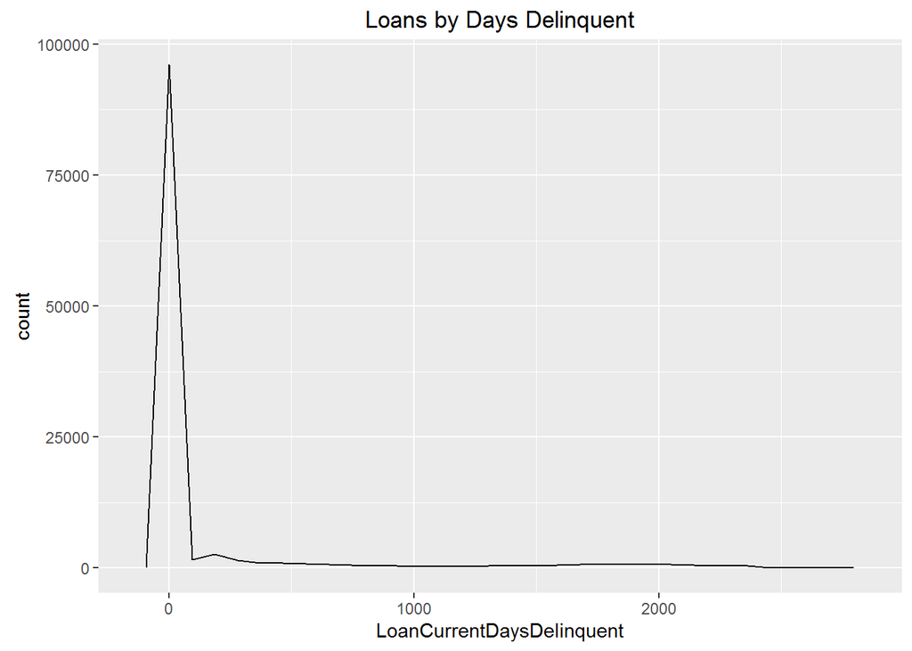

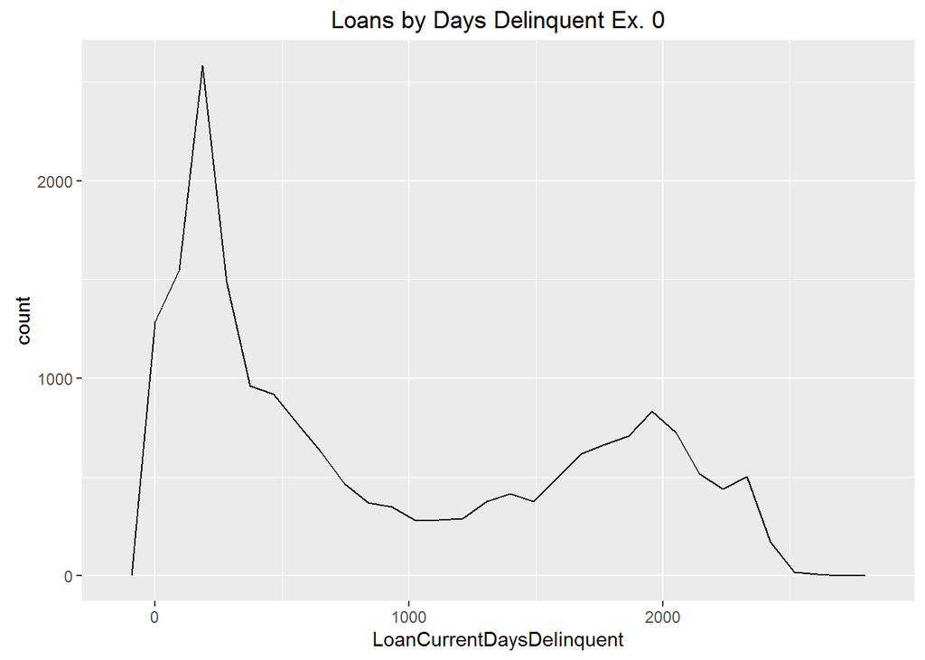

```
##    Min. 1st Qu.  Median    Mean 3rd Qu.    Max.
##     0.0     0.0     0.0   152.8     0.0  2704.0
```

When loans that aren’t delinquent are excluded, a bimodal distribution is formed. This may be because after being delinquent for a certain amount of days, you are more likely to never pay. This would explain the second peak in the data. This could also simple match the volume of loans over time. This will need further analysis in later sections.

### Borrower Profile Variables:

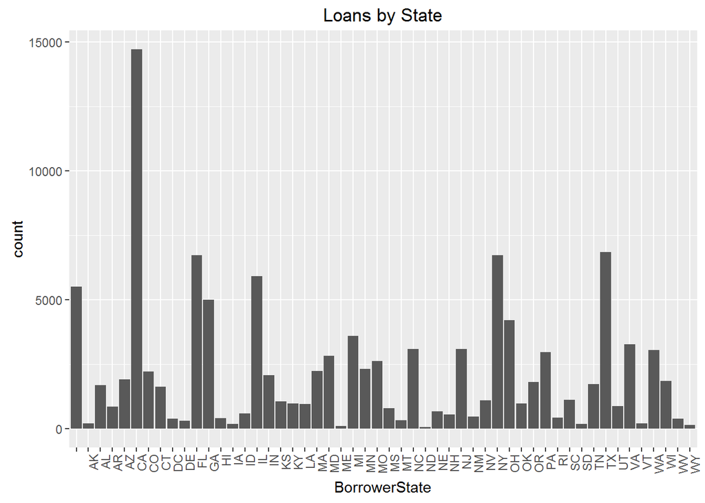

```
##          AK    AL    AR    AZ    CA    CO    CT    DC    DE    FL    GA
##  5512   200  1679   855  1901 14717  2210  1627   382   300  6719  5008
##    HI    IA    ID    IL    IN    KS    KY    LA    MA    MD    ME    MI
##   409   186   599  5921  2078  1062   983   954  2242  2821   101  3593
##    MN    MO    MS    MT    NC    ND    NE    NH    NJ    NM    NV    NY
##  2318  2615   787   330  3083    52   674   551  3097   472  1090  6729
##    OH    OK    OR    PA    RI    SC    SD    TN    TX    UT    VA    VT
##  4197   971  1817  2972   435  1122   189  1737  6842   877  3278   207
##    WA    WI    WV    WY
##  3048  1842   391   150
```

California, Florida, New York and Texas have the most number of borrowers. North Dakota has the least. This could simply be a function of state population. I would like to do futher analysis of loan characteristics by states in later sections.

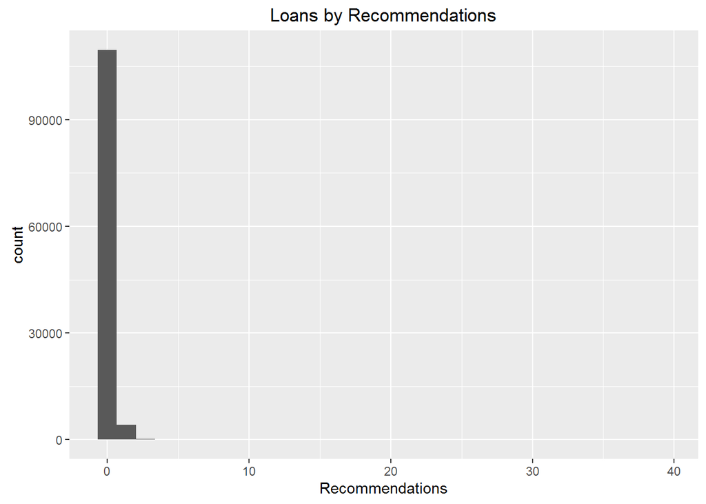

```
##     Min.  1st Qu.   Median     Mean  3rd Qu.     Max.
##  0.00000  0.00000  0.00000  0.04803  0.00000 39.00000
```

More than 75% of the borrowers do not have a recommendation. I concluded that this variable won’t be useful in my exploration and have thus removed it from the data set.

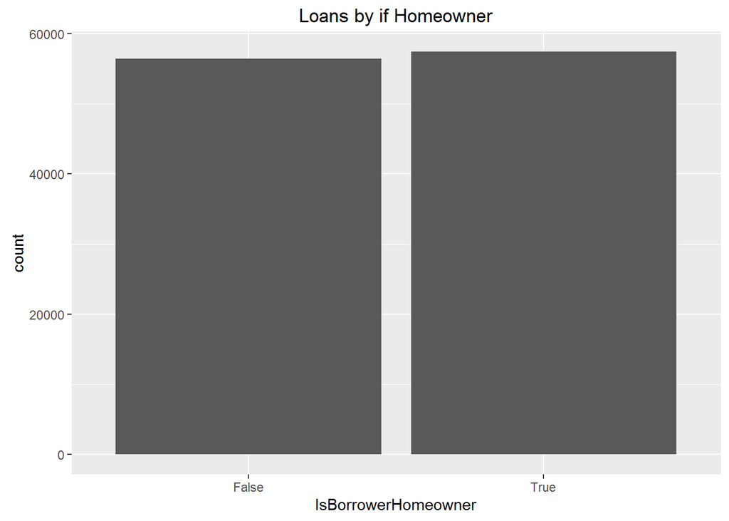

```
## False  True
## 56456 57476
```

About an even number of borrowers are homeowners and non homeowners. The true value in the table represents homeowners and there are 57476 of them.

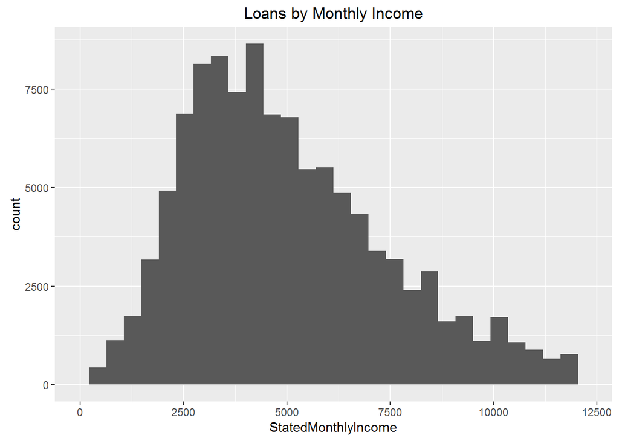

```
##    Min. 1st Qu.  Median    Mean 3rd Qu.    Max.
##       0    3201    4667    5608    6828 1750000
```

The long tailed, positively skewed distribution seems to be affected by large outliers in the data. To adjust for this, I have limited the selection by eliminating the top 5% of data points. This results in a nice normal distribution that has a slight positive skew. I wonder if the large incomes that I have discarded are cases where people lied about their income, or if multimillionairs actually use prosper for loans. I’m leaning towards the former.

### Credit Profile Variables:

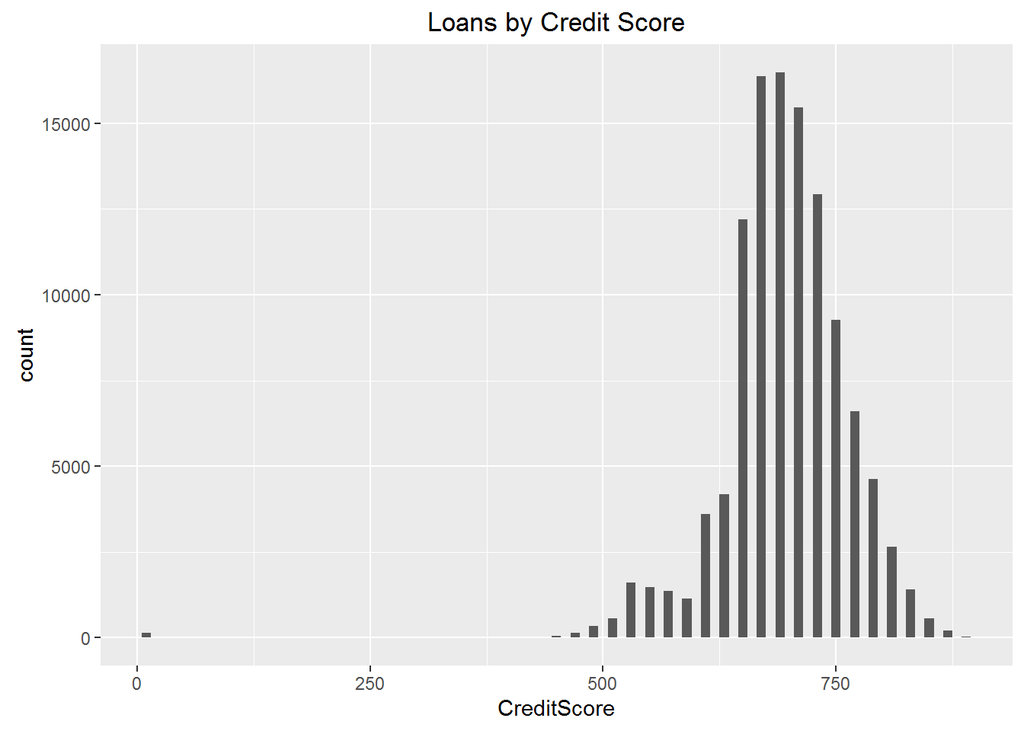

The distribution of credit scores is normally distributed with some gaps in the data. The gaps could be explained by prosper using common intervals for their reporting. There are also some outlier 0 values. I don’t believe anyone actually has a 0 credit score, so this will require further investigation.

```
##
##    10   370   430   450   470   490   510   530   550   570   590   610
##   133     1     5    36   141   346   553  1592  1474  1357  1125  3602
##   630   650   670   690   710   730   750   770   790   810   830   850
##  4172 12198 16366 16492 15471 12922  9267  6606  4624  2644  1409   567
##   870   890
##   212    27
```

[output not shown]

The table shows that no borrower has a credit score of 0. The lowest is 10, which occurs 133 times. Prosper now requires a minimum credit score in the 600s. Initially, however, subprime borrowers could apply for loans. This would explain the low credit scores from before 2008.

```
## df$CreditScore < 100: FALSE
## Defaulted or Chargedoff                Past Due         Current or Paid
##                   16742                    2067                   94400
## --------------------------------------------------------
## df$CreditScore < 100: TRUE
## Defaulted or Chargedoff                Past Due         Current or Paid
##                      94                       0                      39
```

Also, when the data is subsetted for scores below and above 100, it appears that a greater ratio of the lower credit score loans defaulted. 94 out of the 133 are defaulted or chargedoff.

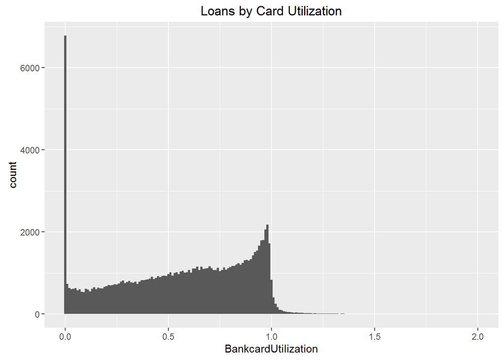

```
##    Min. 1st Qu.  Median    Mean 3rd Qu.    Max.    NA's
##   0.000   0.310   0.600   0.561   0.840   5.950    7600
```

Bank card utilization has two peaks. Interestingly, one peak is at 0 and the other is close to 1. There are also a number of loans that exceed 100% utilization, meaning they owe more then their credit card limits. This makes sense considering most of the loans are used for debt consolidation.

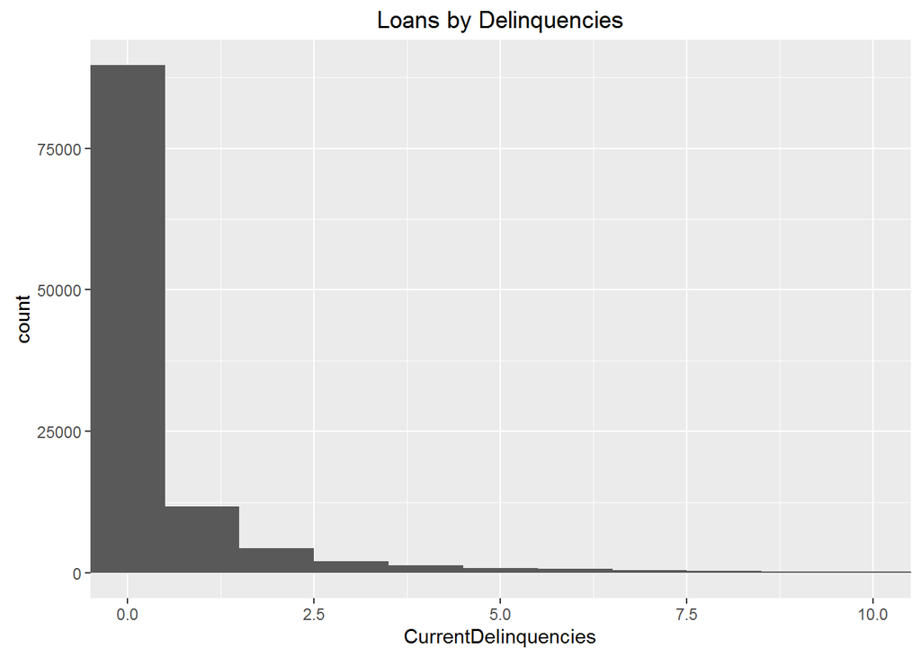

```
##    Min. 1st Qu.  Median    Mean 3rd Qu.    Max.    NA's
##   0.000   0.000   0.000   0.592   0.000  83.000     696
```

Current delinquencies are positively skewed. 75% of loans have no current delinquencies. The max number of delinquencies are 83.

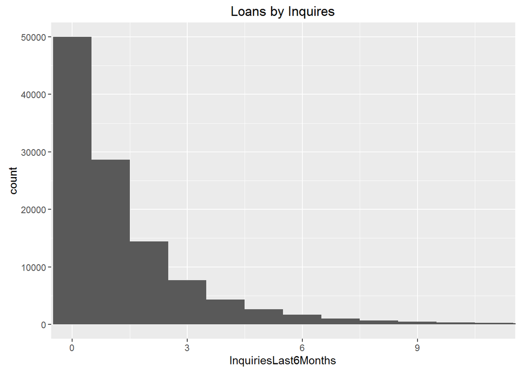

```
##    Min. 1st Qu.  Median    Mean 3rd Qu.    Max.    NA's
##   0.000   0.000   1.000   1.435   2.000 105.000     696
```

Inquires over the previous 6 months show the same skewed distribution as current delinquencies.

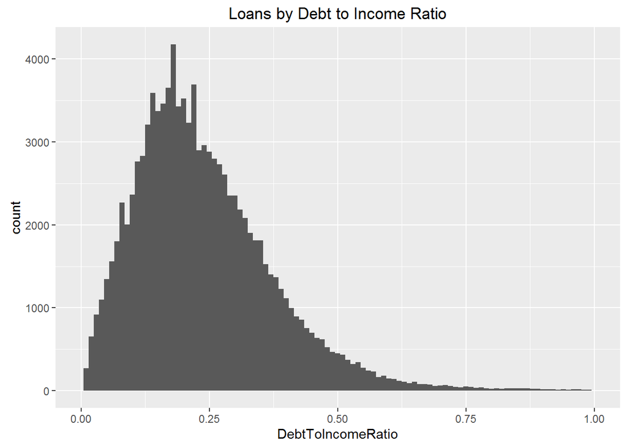

```
##    Min. 1st Qu.  Median    Mean 3rd Qu.    Max.    NA's
##   0.000   0.140   0.220   0.276   0.320  10.010    8554
```

The debt to income ratio is positively skewed with a max of 1000% and a median of 22%.

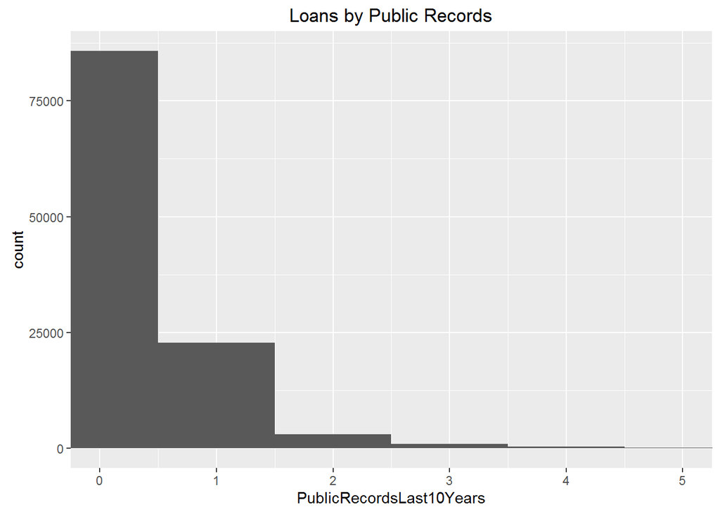

```
##    Min. 1st Qu.  Median    Mean 3rd Qu.    Max.    NA's
##  0.0000  0.0000  0.0000  0.3126  0.0000 38.0000     696
```

Public records over the previous 10 years show the same skewed distribution as current delinquencies and inquiries.

### Variables Subsetted by Loan Status:

```
##                    LoanStatus    LoanOriginationDate  Term
##  Defaulted or Chargedoff:    0   Min.   :2005-11-15   12: 1522
##  Past Due               :    0   1st Qu.:2010-10-26   36:70744
##  Current or Paid        :94855   Median :2012-11-05   60:22589
##                                  Mean   :2011-12-13
##                                  3rd Qu.:2013-10-17
##                                  Max.   :2014-03-12
##
##  TimeUntilClosed           ListingCategory   BorrowerRate
##  Min.   : 0.00   Debt consolidation:52476   Min.   :0.0000
##  1st Qu.: 9.10   Not available     :10265   1st Qu.:0.1274
##  Median :19.50   Other             : 8791   Median :0.1760
##  Mean   :20.42   Home improvement  : 6413   Mean   :0.1849
##  3rd Qu.:35.00   Business          : 5600   3rd Qu.:0.2399
##  Max.   :40.20   Auto              : 2194   Max.   :0.4975
##  NA's   :56781   (Other)           : 9116
##  LoanCurrentDaysDelinquent BorrowerState   IsBorrowerHomeowner
##  Min.   :0                 CA     :12204   False:45987
##  1st Qu.:0                 NY     : 5998   True :48868
##  Median :0                 TX     : 5813
##  Mean   :0                 FL     : 5590
##  3rd Qu.:0                 IL     : 4809
##  Max.   :0                        : 3883
##                            (Other):56558
##  StatedMonthlyIncome  CreditScore    BankcardUtilization
##  Min.   :      0     Min.   : 10.0   Min.   :0.00
##  1st Qu.:   3333     1st Qu.:670.0   1st Qu.:0.31
##  Median :   4927     Median :710.0   Median :0.60
##  Mean   :   5821     Mean   :703.5   Mean   :0.56
##  3rd Qu.:   7083     3rd Qu.:730.0   3rd Qu.:0.83
##  Max.   :1750003     Max.   :890.0   Max.   :5.95
##                      NA's   :416     NA's   :4517
##  CurrentDelinquencies InquiriesLast6Months DebtToIncomeRatio
##  Min.   : 0.0000      Min.   : 0.000       Min.   : 0.000
##  1st Qu.: 0.0000      1st Qu.: 0.000       1st Qu.: 0.150
##  Median : 0.0000      Median : 1.000       Median : 0.220
##  Mean   : 0.4136      Mean   : 1.165       Mean   : 0.263
##  3rd Qu.: 0.0000      3rd Qu.: 2.000       3rd Qu.: 0.310
##  Max.   :51.0000      Max.   :63.000       Max.   :10.010
##  NA's   :463          NA's   :463          NA's   :6848
##  PublicRecordsLast10Years
##  Min.   : 0.0000
##  1st Qu.: 0.0000
##  Median : 0.0000
##  Mean   : 0.2886
##  3rd Qu.: 0.0000
##  Max.   :38.0000
##  NA's   :463
```

```
##                    LoanStatus    LoanOriginationDate  Term
##  Defaulted or Chargedoff:17010   Min.   :2006-01-27   12:   82
##  Past Due               :    0   1st Qu.:2007-05-15   36:15656
##  Current or Paid        :    0   Median :2008-05-12   60: 1272
##                                  Mean   :2009-03-06
##                                  3rd Qu.:2011-06-30
##                                  Max.   :2013-12-31
##
##  TimeUntilClosed            ListingCategory  BorrowerRate
##  Min.   :-45.60   Not available     :6695   Min.   :0.0000
##  1st Qu.: 10.00   Debt consolidation:4700   1st Qu.:0.1700
##  Median : 15.00   Other             :1491   Median :0.2387
##  Mean   : 16.79   Business          :1409   Mean   :0.2318
##  3rd Qu.: 22.10   Home improvement  : 810   3rd Qu.:0.2900
##  Max.   : 51.20   Personal loan     : 775   Max.   :0.4975
##                   (Other)           :1130
##  LoanCurrentDaysDelinquent BorrowerState  IsBorrowerHomeowner
##  Min.   :   1.0            CA     :2306   False:9405
##  1st Qu.: 282.2                   :1629   True :7605
##  Median : 775.5            GA     :1031
##  Mean   :1018.5            IL     :1022
##  3rd Qu.:1772.8            FL     : 983
##  Max.   :2704.0            TX     : 921
##                            (Other):9118
##  StatedMonthlyIncome  CreditScore    BankcardUtilization
##  Min.   :     0      Min.   : 10.0   Min.   :0.0000
##  1st Qu.:  2500      1st Qu.:610.0   1st Qu.:0.2400
##  Median :  3750      Median :650.0   Median :0.6300
##  Mean   :  4451      Mean   :650.8   Mean   :0.5662
##  3rd Qu.:  5417      3rd Qu.:710.0   3rd Qu.:0.8900
##  Max.   :208333      Max.   :870.0   Max.   :4.7300
##                      NA's   :174     NA's   :3083
##  CurrentDelinquencies InquiriesLast6Months DebtToIncomeRatio
##  Min.   : 0.000       Min.   :  0.00       Min.   : 0.0000
##  1st Qu.: 0.000       1st Qu.:  0.00       1st Qu.: 0.1393
##  Median : 0.000       Median :  2.00       Median : 0.2200
##  Mean   : 1.602       Mean   :  2.99       Mean   : 0.3484
##  3rd Qu.: 1.000       3rd Qu.:  4.00       3rd Qu.: 0.3300
##  Max.   :83.000       Max.   :105.00       Max.   :10.0100
##  NA's   :233          NA's   :233          NA's   :1496
##  PublicRecordsLast10Years
##  Min.   : 0.0000
##  1st Qu.: 0.0000
##  Median : 0.0000
##  Mean   : 0.4451
##  3rd Qu.: 1.0000
##  Max.   :30.0000
##  NA's   :233
```

Current or paid loan’s mean origination date is 2011. Defaulted or charged off loan’s mean origination date is 2009. Current or paid loan’s are more likely to be homeowners than defaulted or charged off loans. Average credit scores are 703 vs 650. These diffrences might prove useful in futher analyzing the data.

# Univariate Analysis

### What is the structure of your dataset?

The Prosper Loan dataset contains 81 variables on about 113937 loans made through the prosper.com marketplace. I have further reduced the number of variables to 16 core features and 10 transformations of those features. Variables are of classes int, numeric, date, and factor.

### What is/are the main feature(s) of interest in your dataset?

LoanStatus, LoanOriginationDate, ClosedDate, and BorrowerRate seem to have the most promise for further exploration. I’d like to determine which features are best for predicting the borrower rate on a loan, the time until a loan is closed, and whether or not a loan will go into default.

### What other features in the dataset do you think will help support your investigation into your feature(s) of interest?

ListingCategory, LoanCurrentDaysDelinquent, IsBorrowerHomeowner, StatedMonthlyIncome, BankcardUtilization, CurrentDelinquencies, DebtToIncomeRatio, PublicRecordsLast10Years, and InquiriesLast6Months all seem like good places to start when expanding my investigation.

### Did you create any new variables from existing variables in the dataset?

Yes. I created CreditScore which averages the scores of the upper and lower range provided. I created a LoanOriginationDate.year variable to isolate the year. I created TimeUntilClosed to find the amount of time in months that passed between origination and closing for loans that have closed. I also created a number of bucket variables that I feel will come in useful for multivariate Analysis.

### Of the features you investigated, were there any unusual distributions? Did you perform any operations on the data to tidy, adjust, or change the form of the data? If so, why did you do this?

StatedMonthlyIncome had a very long tail that included values that don’t make sense given size of loans from prosper. Aside from creating new variables, I also reclassified existing variables as factor or date classes where needed.

# Bivariate Plots Section

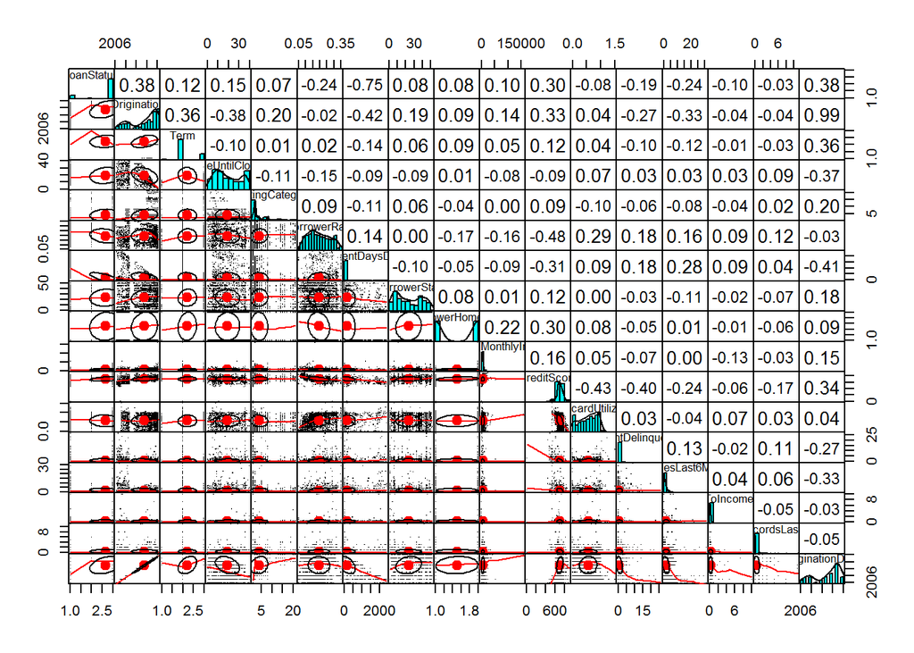

This correlation matrix gives a broad overview of feature interactions. Some interesting relationships for further anaysis are as follows: * BorrowerRate vs LoanStatus, CreditScore, BankcardUtilization * TimeUntilClosed vs LoanOriginationDate.year, Term, Listing Category, BorrowerRate, CreditScore * LoanStatus vs LoanOriginationDate.year, BorrowerRate, LoanCurrentDaysDelinquent, CreditScore, CurrentDelinquencies, InquiriesLast6Months

### BorrowerRate Exploration

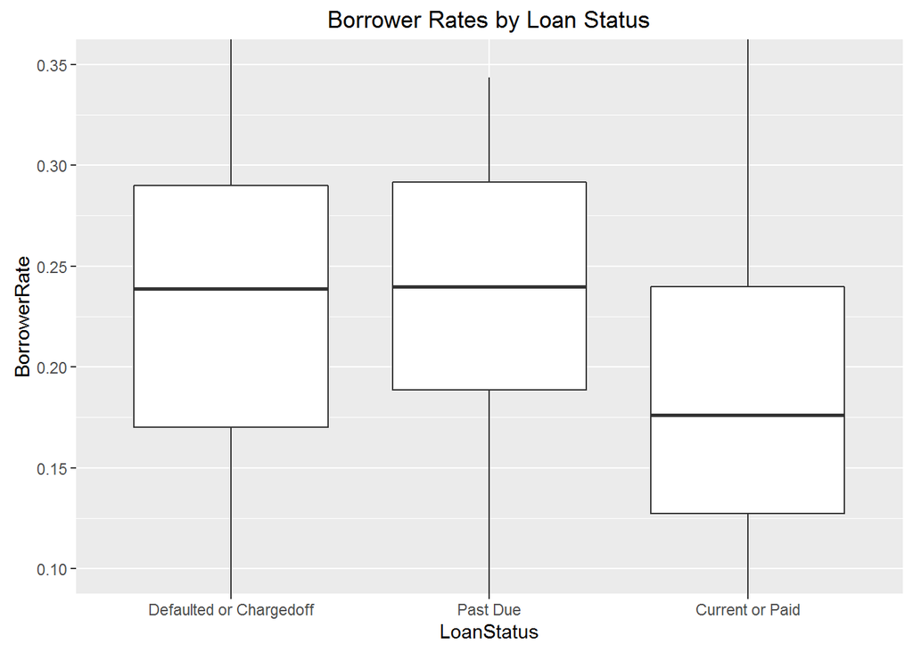

The median borrower rate for current or paid loans is significantly lower than other loan types. This could be because it is easier to service loans with lower interest rates. It could also be because lower interest rates are given to people most likely to make payments.

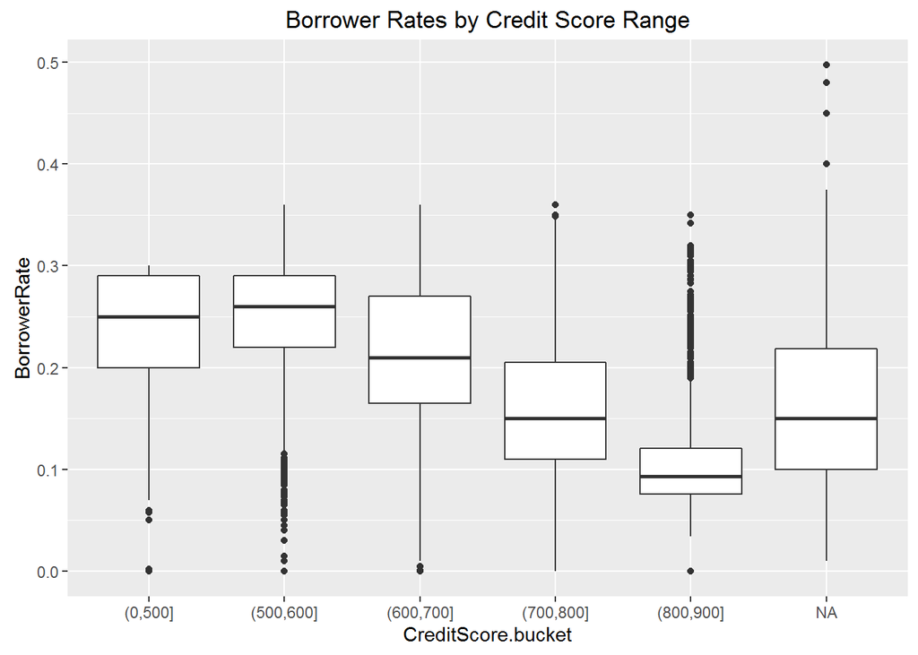

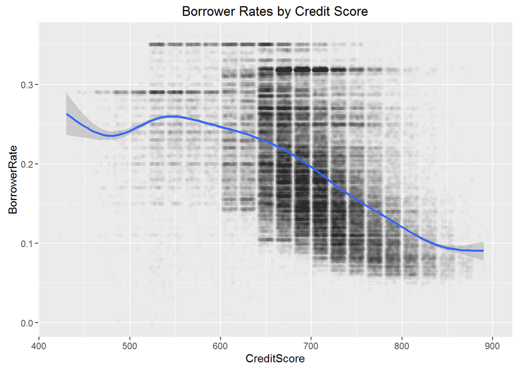

As expected, the interest rate borrowers are charged is inversely related to their credit score. However, there remains a large dispersion of outliers at ever range of credit scores.

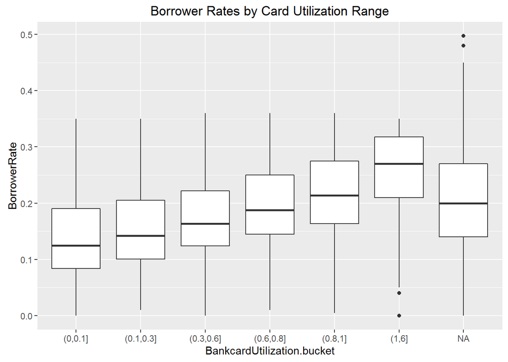

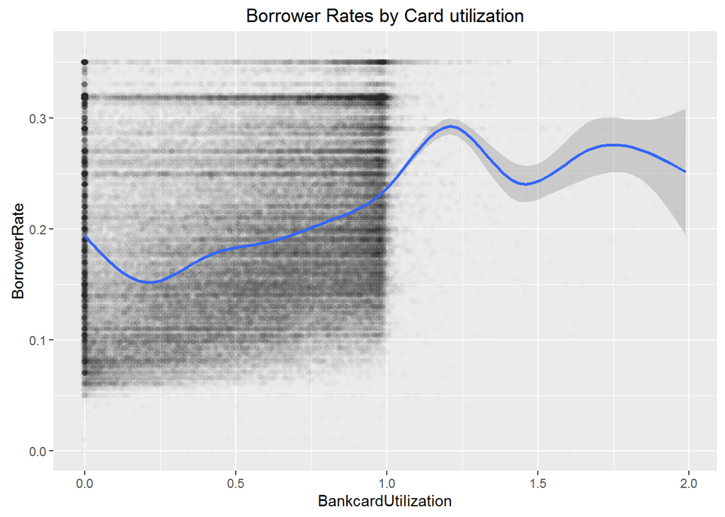

When grouped into buckets, an expected relationship between interest rates and credit utilization emerges. However, when every point is plotted, no solid relationship exists.

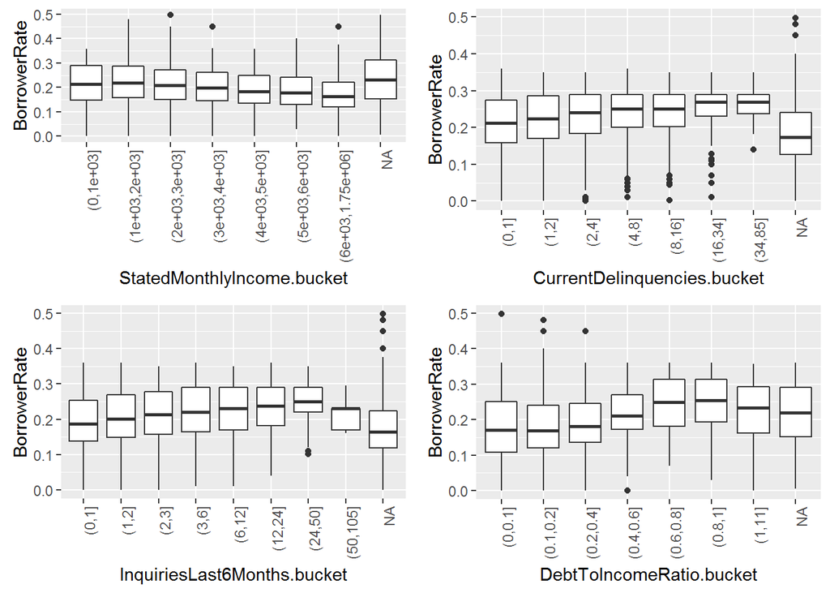

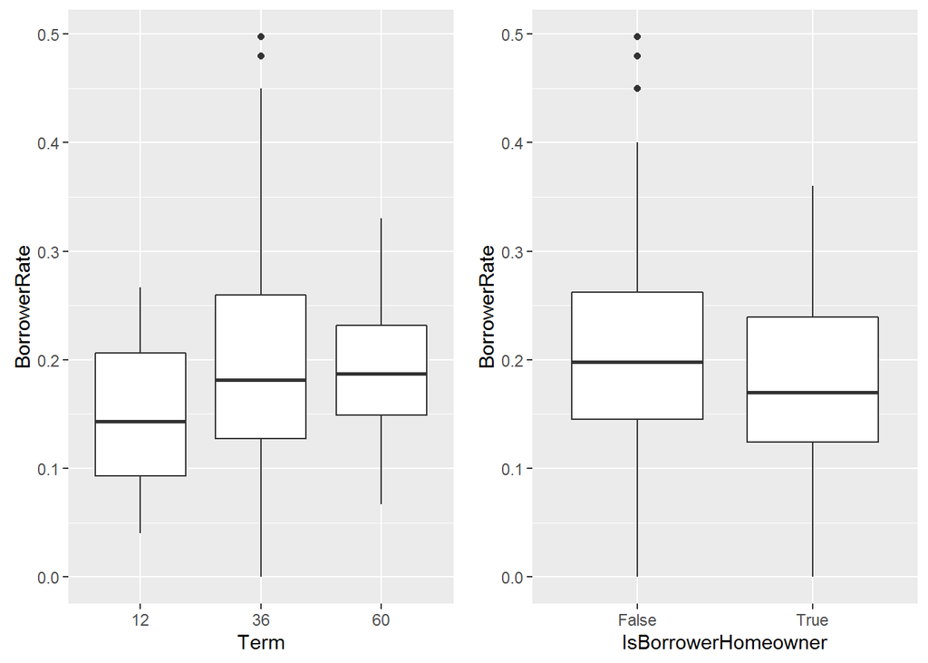

Many of the other credit factors show similar relationships as credit score. This is most likely because credit score is a function of the other credit factors. Term and homeownership also seem to have a slight relationship with BorrowerRate. In summary, the worse your credit factors, the more interest a loan is going to cost you. The longer the loan duration, the more interest a loan is going to cost you. If you are a homeowner you will probably be charged less interest on a loan.

### TimeUntilClosed Exploration

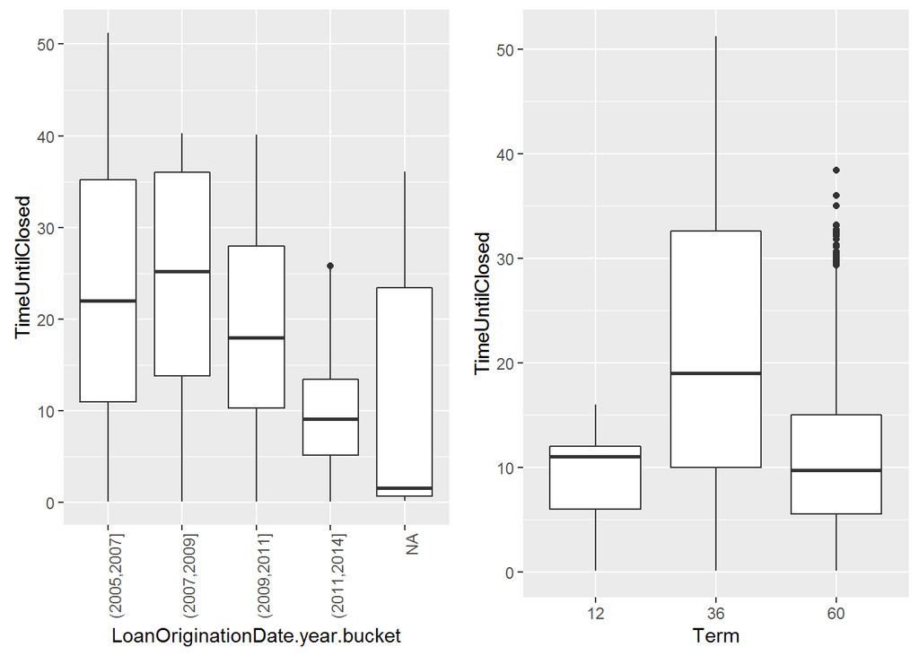

What stands out to me here is that loans with term 60 actually close at a faster rate than loans with term 36. This is not intuitive, as I thought loans with longer terms would close on average over longer times. I will analyze this further in later sections.

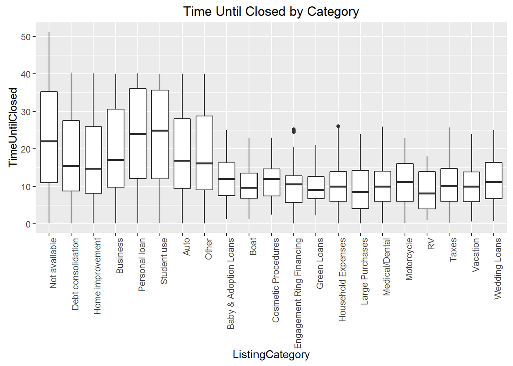

Personal loans and student loans appear to take the longest to close. This makes some sense, as people tend to give the lowest priority to student loans and credit cards.

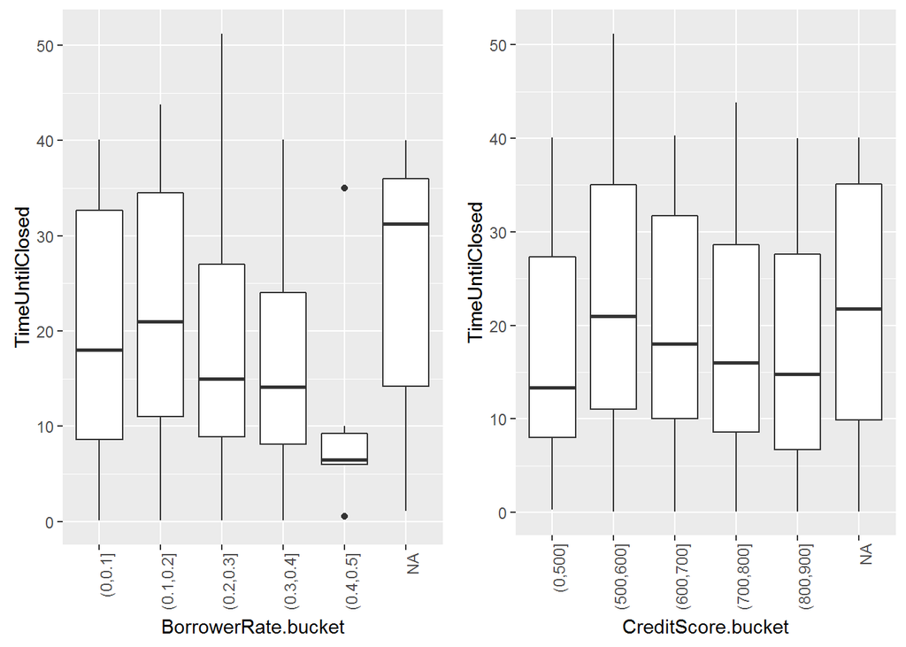

High rates and high credit scores tend to correspond with quicker closing times. This makes sense as you would want to prepay a loan with a high rate. There is also a spike in the speed it takes to close loans of really low rates and credit scores. This could be because low credit scores default faster and because low rates tend to be given for the lowest term loans.

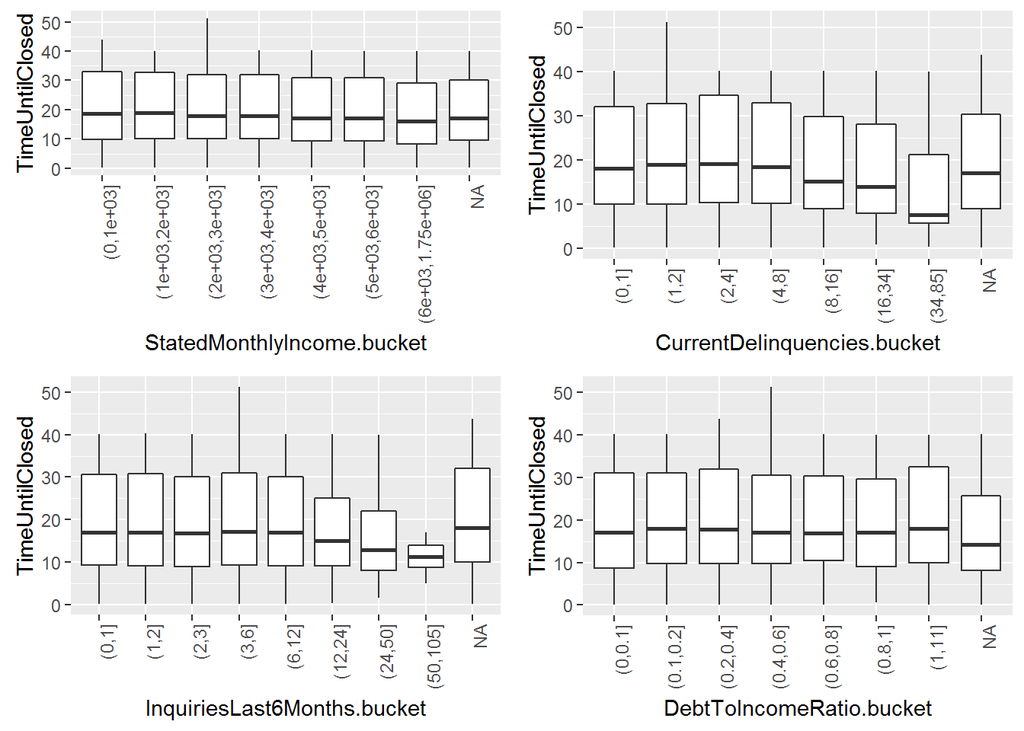

Most of this isn’t interesting, however, having more inquires over the past 6 months tends to mean a quicker time until the loan is closed. Since loans might be closed for conflicting reasons, prepaid vs default, it might turn out to be difficult to model this aspect without breaking out the reasons for the loan being closed. This could be done by sub setting by loan status.

```
## df$LoanStatus: Defaulted or Chargedoff
##    Min. 1st Qu.  Median    Mean 3rd Qu.    Max.
##  -45.60   10.00   15.00   16.79   22.10   51.20
## --------------------------------------------------------
## df$LoanStatus: Past Due
##    Min. 1st Qu.  Median    Mean 3rd Qu.    Max.    NA's
##      NA      NA      NA     NaN      NA      NA    2067
## --------------------------------------------------------
## df$LoanStatus: Current or Paid
##    Min. 1st Qu.  Median    Mean 3rd Qu.    Max.    NA's
##    0.00    9.10   19.50   20.42   35.00   40.20   56781
```

In later sections, it will probably make more sense to predict the time until closed for loans that are defaulted or chargedoff. I will only be interested predicting when a loan will be closed if it goes into default.